# DAUF workshop

Data. Visuals. Insights.

## Data -> Visuals -> Insights

Data wrangling - access required **data sources**

- access data sources (from object storage, Web APIs, databases)
- use `tidyverse` APIs (filter, group, summarise, pivot, transform)

Design appropriate **visuals** (tables, diagrams, maps etc)

- use static plots (`ggplot2` works across most formats, including print)
- use interactive widgets (`htmlwidgets` can be used in HTML / browsers)

Provide a coherent **presentation** / story / narrative, including explanations

- use `quarto` for interactive reports
- provide access via an app or API

## Data wrangling

Utilize the manipulation “grammar” [offered by `tidyverse`](https://www.tidyverse.org/packages/):

- `dplyr` - “everything SQL provides and then some more”
- `tidyr` - pivoting into long or wide format

Techniques:

- new: support for `.by` parameter, see this [link](https://www.tidyverse.org/blog/2023/02/dplyr-1-1-0-per-operation-grouping/#per-operation-grouping-with-byby)
- mutate: row-wise and/or column-wise?
- dealing with nested data

## Resources / links

Working with rows and columns:

- [Row-wise operations](https://dplyr.tidyverse.org/articles/rowwise.html)
- [Column-wise operations](https://dplyr.tidyverse.org/articles/colwise.html)
- [Nested data](https://tidyr.tidyverse.org/articles/nest.html#nested-data-and-models)
- [Performance optimization](https://www.tidyverse.org/blog/2023/04/performant-packages/)

New verbs and functionality:

- [“by” - per operation](https://www.tidyverse.org/blog/2023/02/dplyr-1-1-0-per-operation-grouping/#per-operation-grouping-with-byby)
- [“pick” and “reframe”](https://www.tidyverse.org/blog/2023/02/dplyr-1-1-0-pick-reframe-arrange/)
- [“pipes”](https://www.tidyverse.org/blog/2023/04/base-vs-magrittr-pipe/)

## Visuals - graphs

Static [ggplot2 graph gallery](https://r-graph-gallery.com/)

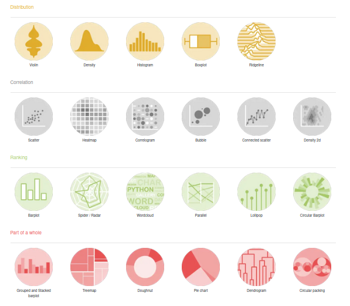

ggplot2 graphs (1)

[figure not shown]

ggplot2 graphs (2)

## Visuals - widgets

Interative [HTML Widgets gallery](http://gallery.htmlwidgets.org/), see [showcase link](http://www.htmlwidgets.org/showcase_leaflet.html%3E)

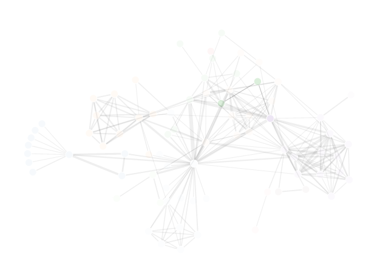

Widgets

## Example: Swecris projects

Getting data from Swecris (Web API) - for KTH …

Do we get any special fields / nested data / “list columns”?

```r
# get some data over the web API
library(tidyverse)
library(swecris)

# what are all organisations?
orgs <- swecris_organisations()

# what is KTHs identifier?
id_kth <- orgs |>
  filter(str_detect(organisationNameSv, "KTH, Kungliga")) |>
  pull("organisationId")

# all information about projects from KTH
projects <- id_kth |> swecris_projects()

# non-character columns, which are those?
glimpse(projects |> select(where(Negate(is.character))))
```

```
Rows: 3,174
Columns: 4
$ fundingsSek   <int> 1108000, 1065000, 2740000, 2522000, 2456000, 2109000, 47…
$ typeOfAwardId <int> 999, 999, 999, 999, 999, 999, 999, 999, 999, 999, 999, 9…
$ peopleList    <list> <NULL>, <NULL>, <NULL>, <NULL>, <NULL>, <NULL>, <NULL>,…
$ scbs          <list> [["99999", "Oklassificerat", "Unclassified", "999", "Ok…
```

## Table of Swecris projects

Lets take a look at a few samples of Swecris projects data

```r
projects |>
  rowwise() |>
  mutate(has_people = length(peopleList) > 0) |>
  filter(has_people, !is.na(projectTitleEn)) |>
  head(2) |>
  select(any_of(c("projectId", "projectTitleEn", "peopleList", "scbs"))) |>
  knitr::kable()
```

| projectId | projectTitleEn | peopleList | scbs |
| --- | --- | --- | --- |
| 2007-00381_Formas | Reducing the production time for underground construction through efficient use of shotcrete in environments exposed to vibrations | 55583 , Anders Ansell , 0000-0001-8336-1247 , Principal Investigator, Projektledare , Male | 99999 , Oklassificerat, Unclassified , 999 , Oklassificerat, Unclassified , 9 , Oklassificerat, Unclassified |
| 2007-00587_Formas | FiberSurf - New biotechnological tools for wood fiber modification and analysis | 50182 , Harry Brumer , , Principal Investigator, Projektledare , - | 99999 , Oklassificerat, Unclassified , 999 , Oklassificerat, Unclassified , 9 , Oklassificerat, Unclassified |

## Example: Swecris people

Shows how to untangle information about the people associated with projects into a separate dataset which can be stored in a relational database (ie has projectId and peopleId as well as other fields with information about people)

```r
# use the list column to create a table of people connected to projects
people <-
  projects |> select(x = projectId, y = peopleList) |>
  pmap(.progress = TRUE, function(x, y, ...)
    bind_rows(y) |> mutate(projectId = x)
  ) |>
  bind_rows()

people |> head(3) |> knitr::kable()
```

| projectId | personId | fullName | orcId | roleEn | roleSv | gender |
| --- | --- | --- | --- | --- | --- | --- |
| 2006-00810_VR | 53438 | James R Drake |  | Principal Investigator | Projektledare | - |
| 2006-08013_VR | 73034 | Marek Rubel | 0000-0001-9901-6296 | Principal Investigator | Projektledare | Male |
| 2007-00381_Formas | 55583 | Anders Ansell | 0000-0001-8336-1247 | Principal Investigator | Projektledare | Male |

## Example: summary for Swecris people

We now have a separate table for people and can use it for summaries, joins etc:

```
# A tibble: 2 × 4
  roleEn                 n_people n_projects n_orcids
  <chr>                     <int>      <int>    <int>
1 Principal Investigator     1092       2727      659
2 Co-Investigator            1034        670      696
```

## Challenge: Which authors have ORCiDs but no DiVA authority person?

Example from yesterday….

> In DiVA, which authors have publications where ORCiD is registered, but there may be no kthid for the author or no DiVA authority person identifier?

## Hints

Lets help each other out with this challenge…

- Getting the data
- Choosing an appropriate visual (table / diagram / graph)
- Presenting the results in an understandable way

> Hint: There is the `aut.csv` file from `data.bibliometrics.lib.kth.se` in the `kthcorpus`-bucket.

> Hint: Alternatively, the R-package “kthcorpus” has a function `kth_diva_authors()` which can be used to get a table of KTH authors and their corresponding publications.

## Example solution

There are many ways to approach the challenge, here is one:

- see https://github.com/KTH-Library/kthcorpus/blob/main/inst/rmarkdown/orcid_report.qmd#L256-L271

[figure not shown]

DAUF workshop